# SCRIPT Bulk QC and Cleaning

# Goals

1. Process counts tables generated in 200526_bulk_sequence_processing.Rmd and ensure relatively consistent quality across batches, lack of batch effect. Apply batch correction as necessary.
2. Remove problem lanes and samples
3. Determine source of poor alignment and assignent, if any

# Setup

## Load packages

```r
library(viridis)
```

## Import data

### Metadata

log in to google drive (must be done interactively)

```r
drive_auth(use_oob = T) # have to run in console :(
gs4_auth(token = drive_token())
```

```r
rna_metadata = read_sheet("https://docs.google.com/spreadsheets/d/15aq9UMRtTl5E75E5M0mXvbFfxVVuJxrXneKYpo6LzlE/edit#gid=897409272",
                  trim_ws = T,
                  .name_repair = "universal",
                  sheet = "SCRIPT_01 RNAseq Metadata",
                  na = c("", "NA"))
```

```
Reading from "SCRIPT_01_RNAseq"
Range "'SCRIPT_01 RNAseq Metadata'"
* `` -> ...17
* `` -> ...19
* `Kit lot number` -> Kit.lot.number
* `Elution vol (ul)` -> Elution.vol..ul.
* `Date of RNA QC` -> Date.of.RNA.QC
* ...
```

```r
#clean up colnames
colnames(rna_metadata) = gsub("\\.", "_", colnames(rna_metadata)) #I like underscores
colnames(rna_metadata) = gsub("_+$", "", colnames(rna_metadata)) # remove trailing
colnames(rna_metadata) = gsub("_+", "_", colnames(rna_metadata)) #remove dup underscores
#tube is randomly read in as a list. fix this.
rna_metadata$tubeid_macrophRNA = as.character(rna_metadata$tubeid_macrophRNA)
rna_metadata$tubeid_macrophRNA[rna_metadata$tubeid_macrophRNA == "NULL"] = NA
#take out problem cols (added back)
rna_metadata = rna_metadata %>%
  dplyr::select(-c(RNAseq_batch, Batch_sample))

#keep track of batches
batch_metadata = read_sheet("https://docs.google.com/spreadsheets/d/15aq9UMRtTl5E75E5M0mXvbFfxVVuJxrXneKYpo6LzlE/edit#gid=897409272",
                  trim_ws = T,
                  .name_repair = "universal",
                  sheet = "SCRIPT_01 RNAseq Library prep layouts",
                  na = c("", "NA"))
```

```
Reading from "SCRIPT_01_RNAseq"
Range "'SCRIPT_01 RNAseq Library prep layouts'"
* `Library prep date` -> Library.prep.date
* `RNA tube ID` -> RNA.tube.ID
* `Library prep plate` -> Library.prep.plate
* `Library size (bp)` -> Library.size..bp.
* `Index i7` -> Index.i7
* ...
```

```r
batch_metadata = batch_metadata %>%
  dplyr::select(-c(Library.prep.date, Comments)) %>%
  mutate_at(.vars = "RNA.tube.ID", function(x){
    x = gsub("R", "", as.character(x), ignore.case = T)})

#merge with rna metadata to account for repeats
rna_metadata = left_join(rna_metadata,
                         batch_metadata,
                         by = c("tubeid_macrophRNA" = "RNA.tube.ID"))

#clean up colnames
colnames(batch_metadata) = gsub("\\.", "_", colnames(batch_metadata)) #I like underscores
colnames(batch_metadata) = gsub("_+$", "", colnames(batch_metadata)) # remove trailing
colnames(batch_metadata) = gsub("_+", "_", colnames(batch_metadata)) #remove dup underscores
#ignore samples for now
batch_metadata = batch_metadata %>%
  dplyr::select(RNAseq_batch, Sequencing_Run_ID) %>%
  na.omit() %>%
  unique() %>%
  filter(!duplicated(RNAseq_batch)) #this ignores repeats for now. Not really relevant to "batch"
batch_metadata = rbind(batch_metadata, c("SCRIPT_RNAseq_Batch_07", "SCRIPT_BATCH_07")) #account for basespace transfer
batch_metadata = as.data.frame(batch_metadata)
```

### Pipeline QC data

```r
seq_dirs = dir(path = "/projects/b1038/Pulmonary/rgrant/script_bulk",
               all.files = F,
               full.names = T,
               recursive = F)
mqc_tables = mclapply(seq_dirs, function(dir){
  if(grepl("200520_NB501488_0357_AHHVH5BGXF_copy_RAG", dir)) #because of testing file structure is different
  {
    mqc_path = paste0(dir, "/GRCh37_comparison/results/MultiQC/multiqc_data/multiqc_general_stats.txt")
  } else
  {
    mqc_path = paste0(dir, "/results/MultiQC/multiqc_data/multiqc_general_stats.txt")
  }

  mqc = read.delim(mqc_path)

  #make sure all samples have unique names (hURNA and repeats)
  run = gsub("_copy_RAG", "", basename(dir))
  batch = batch_metadata[which(batch_metadata$Sequencing_Run_ID == run), "RNAseq_batch"]
  mqc$batch = batch
  return(mqc)
})
```

### Counts tables

```r
name_conversion = read.delim("/projects/b1038/Pulmonary/rgrant/script_bulk/200528_NB501488_0359_AHVYTKBGXF_copy_RAG/results/featureCounts/merged_gene_counts.txt") %>%
  dplyr::select(gene_name, Geneid) %>%
  column_to_rownames(var = "Geneid") #for later conversion due to mixed IDs
counts_tables = mclapply(seq_dirs, function(dir){
  if(grepl("200520_NB501488_0357_AHHVH5BGXF_copy_RAG", dir)) #because of testing file structure is different
  {
    counts_path = paste0(dir, "/GRCh37_comparison/results/featureCounts/merged_gene_counts.txt")
  } else
  {
    counts_path = paste0(dir, "/results/featureCounts/merged_gene_counts.txt")
  }

  counts = read.delim(counts_path) %>%
    dplyr::select(-gene_name) #really nice feature but can't make a matrix this way

  #make sure all samples have unique names (hURNA and repeats)
  run = gsub("_copy_RAG", "", basename(dir))
  batch = batch_metadata[which(batch_metadata$Sequencing_Run_ID == run), "RNAseq_batch"]
  colnames(counts) = gsub("Aligned.sortedByCoord.out.bam",
                          paste0("_", batch),
                          colnames(counts))
  return(counts)
})

#merge into single table
merged_counts = counts_tables %>%
  purrr::reduce(full_join, by = "Geneid") %>%
  column_to_rownames(var = "Geneid")
#clean up sample names
colnames(merged_counts) = gsub("^X", "", colnames(merged_counts))

#clean up workspace
rm(counts_tables)
```

## Construct DESeq dataset

```r
#strip sample data
md = data.frame(lane_run = colnames(merged_counts))
md$sample = factor(substring(md$lane_run, 1, (regexpr("_S\\d", md$lane_run) - 1)))
md$sample_num = factor(substring(md$lane_run, (regexpr("_S\\d", md$lane_run) + 1), (regexpr("_L", md$lane_run) - 1)))
md$lane = factor(substring(md$lane_run, (regexpr("_L", md$lane_run) + 1), (regexpr("_R", md$lane_run) - 1)))
md$run = factor(substring(md$lane_run, (regexpr("_R\\d", md$lane_run) + 1), (regexpr("_\\d{3}", md$lane_run) - 1)))
md$number = factor(substring(md$lane_run, (regexpr("_\\d{3}", md$lane_run) + 1), (regexpr("_SC", md$lane_run) - 1)))
md$batch = factor(substring(md$lane_run, (regexpr("_SC", md$lane_run) + 1)))
md$sample_type = factor(ifelse(grepl("hURNA", md$sample),
                        yes = "hURNA_control",
                        no = "sample"))

#merge with RNA metadata
md = left_join(md, rna_metadata, by = c("sample" = "tubeid_macrophRNA", "batch" = "RNAseq_batch"))

#merge with clinical metadata
clinical_md = readRDS("/projects/p30623/Box/rgrant/SCRIPT/2020-06-02_SCRIPT_clinical_metadata_processed.rds")
md = left_join(md, clinical_md, by = c("tc_pt_study_id" = "sample_id"))
rownames(md) = md$lane_run
md$sample_batch = paste(md$sample, md$batch, sep = "_") #these should be unique

#merge with mutliqc metadata
md = left_join(md, mqc_metadata, by = c("lane_run", "batch"))

#update cols as necessary
md$COVID = ifelse(md$COVID_status == "COVID+",
                  yes = T,
                  no = F)
md$COVID[is.na(md$COVID)] = F #not terribly safe but necessary for now

script_bulk = DESeqDataSetFromMatrix(countData = merged_counts,
                                     colData = md,
                                     design = ~ COVID + batch)
```

```
some variables in design formula are characters, converting to factors
```

```r
dim(md)
```

```
[1] 656 258
```

# QC

## Alignment and assignment

### ANOVA

```r
summary.aov(fit)
```

```
 Response 1 :
              Df  Sum Sq Mean Sq F value    Pr(>F)
RIN            1    50.7   50.66  0.8507    0.3572
batch          6  7328.8 1221.46 20.5099 < 2.2e-16 ***
Operator_RNA   1  3091.4 3091.37 51.9080 6.782e-12 ***
Residuals    251 14948.2   59.55
---
Signif. codes:  0 ‘***’ 0.001 ‘**’ 0.01 ‘*’ 0.05 ‘.’ 0.1 ‘ ’ 1

 Response 2 :
              Df Sum Sq Mean Sq F value    Pr(>F)
RIN            1   15.1   15.13  0.6195     0.432
batch          6 4326.4  721.06 29.5183 < 2.2e-16 ***
Operator_RNA   1  962.6  962.62 39.4070 1.502e-09 ***
Residuals    251 6131.3   24.43
---
Signif. codes:  0 ‘***’ 0.001 ‘**’ 0.01 ‘*’ 0.05 ‘.’ 0.1 ‘ ’ 1

396 observations deleted due to missingness
```

Hard to differentiate batch and operator, but I had a feelign this would be the case. My numbers are clearly lower. Very surprising that RIN contributes little.

### Plotting

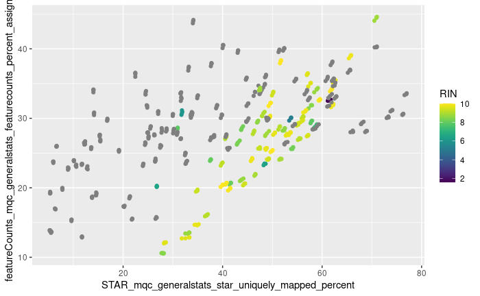

```r
ggplot(md, aes(x = STAR_mqc_generalstats_star_uniquely_mapped_percent,
               y = featureCounts_mqc_generalstats_featurecounts_percent_assigned,
               color = RIN)) +
  geom_point() +
  scale_color_viridis()
```

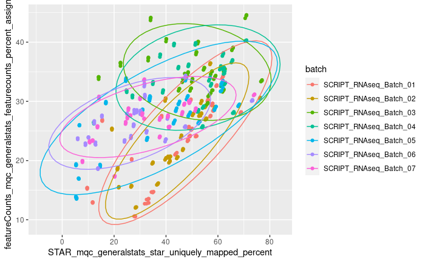

```r
ggplot(md, aes(x = STAR_mqc_generalstats_star_uniquely_mapped_percent,
               y = featureCounts_mqc_generalstats_featurecounts_percent_assigned,
               color = batch)) +
  geom_point() +
  stat_ellipse()
```

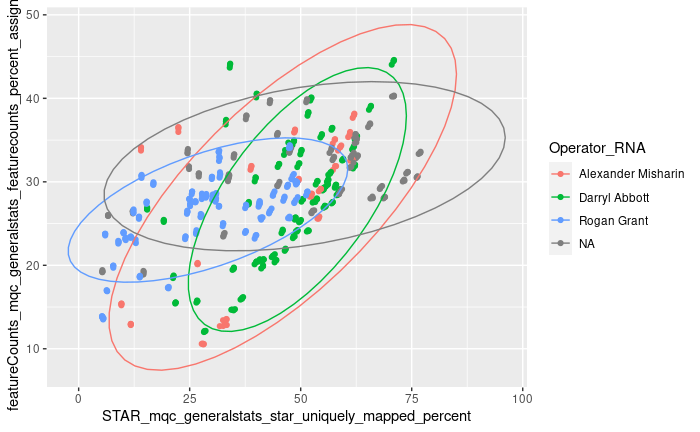

```r
ggplot(md, aes(x = STAR_mqc_generalstats_star_uniquely_mapped_percent,
               y = featureCounts_mqc_generalstats_featurecounts_percent_assigned,
               color = Operator_RNA)) +
  geom_point() +
  stat_ellipse()
```

So it goes. Unfortunately hard to guess what might be going on here. I will be faster and more careful preparing plates in the future. Surprisingly the RIN correlation truly does seem to be low, although the nunbers are clearly skewed.

## Identify bad lanes

### PCA

With hURNA

```r
d = plotPCA(vst(script_bulk),
        intgroup = c("sample_batch"),
        returnData = T)
ggplot(d, aes(x = PC1, y = PC2, color = sample_batch)) +
   geom_point() +
   stat_ellipse(aes(x = PC1, y = PC2, color = sample_batch), inherit.aes = F) +
  theme(legend.position = "none")
```

[output not shown]

Without

```r
d = plotPCA(vst(script_bulk_samples),
        intgroup = c("sample_batch"),
        returnData = T)
ggplot(d, aes(x = PC1, y = PC2, color = sample_batch)) +
   geom_point() +
   stat_ellipse(aes(x = PC1, y = PC2, color = sample_batch), inherit.aes = F) +
  theme(legend.position = "none")
```

[output not shown]

### Collapse lanes

```r
script_bulk = collapseReplicates(script_bulk,
                                 groupby = script_bulk$sample_batch)
script_bulk_samples = collapseReplicates(script_bulk_samples,
                                 groupby = script_bulk_samples$sample_batch)
```

## Determine what to do with repeats

### Add repeat flag

```r
script_bulk$is_repeat = duplicated(script_bulk$sample) & script_bulk$sample_type == "sample"
script_bulk_samples$is_repeat = duplicated(script_bulk_samples$sample)
repeated_samples = script_bulk$sample[script_bulk$is_repeat]
```

### PCA

```r
d = plotPCA(vst(script_bulk_samples),
        intgroup = c("sample_batch", "sample", "is_repeat"),
        returnData = T)
d$highlight = d$sample %in% repeated_samples
ggplot(NULL) +
  geom_point(data = d, aes(x = PC1, y = PC2), alpha = 0.2) +
  geom_point(data = subset(d, highlight), aes(x = PC1, y = PC2, color = sample, shape = is_repeat), alpha = 1, size = 3)
```

[output not shown]

## Batch effects

### PCA

With hURNA

```r
d = plotPCA(vst(script_bulk),
        intgroup = c("batch", "sample_type"),
        returnData = T)
ggplot(d, aes(x = PC1, y = PC2, color = batch, shape = sample_type)) +
   geom_point() +
   stat_ellipse(aes(x = PC1, y = PC2, color = batch, linetype = sample_type), inherit.aes = F)
```

[output not shown]

```r
script_bulk = script_bulk[, script_bulk$sample != "340228404"]
script_bulk_samples = script_bulk_samples[, script_bulk_samples$sample != "340228404"]
```

With hURNA after cleaning

```r
d = plotPCA(vst(script_bulk),
        intgroup = c("batch", "sample_type"),
        returnData = T)
ggplot(d, aes(x = PC1, y = PC2, color = batch, shape = sample_type)) +
   geom_point() +
   stat_ellipse(aes(x = PC1, y = PC2, color = batch, linetype = sample_type), inherit.aes = F)
```

[output not shown]

Without

```r
d = plotPCA(vst(script_bulk_samples),
        intgroup = c("batch", "sample_type"),
        returnData = T)
ggplot(d, aes(x = PC1, y = PC2, color = batch, shape = sample_type)) +
   geom_point() +
   stat_ellipse(aes(x = PC1, y = PC2, color = batch, linetype = sample_type), inherit.aes = F)
```

[output not shown]